# Session_08b

### Time Series

This week you have learned the fundamentals of time series. The goal of this exercise is to make useful visualizations on a time series dataset.

**Time Series** is a sequence of observations recorded at different time periods Time series may depend on different frequencies such as hours, weeks, months and years. Certain examples of time series are:

- Stock prices per day
- Production of a product
- Global Daily Temperature

After this session you will be able to:

- observe how time affects a variable
- inspect periodic fluctuations (seasonality)
- evaluate the variable alterations year (trend) and monthly wise (different way of seasonality visualization)

In the next session we will dive deeper in time series with stationarity testing, detrending techniques, ARIMA models and more.

```python
from dateutil.parser import parse
import matplotlib as mpl
import matplotlib.pyplot as plt
import seaborn as sns
import numpy as np
import pandas as pd

sns.set_style("whitegrid")
plt.rc('xtick', labelsize=15)
plt.rc('ytick', labelsize=15)
```

#### 1. Import a dataset with daily drug sales

This dataset contains different drug types in the columns and the dates and other time recording intervals

```python
df = pd.read_csv('data\salesdaily.csv')
df.head()
```

|  | datum | M01AB | M01AE | N02BA | N02BE | N05B | N05C | R03 | R06 | Year | Month | Hour | Weekday Name |
| --- | --- | --- | --- | --- | --- | --- | --- | --- | --- | --- | --- | --- | --- |
| 0 | 1/2/2014 | 0.0 | 3.67 | 3.4 | 32.40 | 7.0 | 0.0 | 0.0 | 2.0 | 2014 | 1 | 248 | Thursday |
| 1 | 1/3/2014 | 8.0 | 4.00 | 4.4 | 50.60 | 16.0 | 0.0 | 20.0 | 4.0 | 2014 | 1 | 276 | Friday |
| 2 | 1/4/2014 | 2.0 | 1.00 | 6.5 | 61.85 | 10.0 | 0.0 | 9.0 | 1.0 | 2014 | 1 | 276 | Saturday |
| 3 | 1/5/2014 | 4.0 | 3.00 | 7.0 | 41.10 | 8.0 | 0.0 | 3.0 | 0.0 | 2014 | 1 | 276 | Sunday |
| 4 | 1/6/2014 | 5.0 | 1.00 | 4.5 | 21.70 | 16.0 | 2.0 | 6.0 | 2.0 | 2014 | 1 | 276 | Monday |

#### 2. Index the data by date

We have to transform the data to index them by date so that we can perform different aggregations and be able to see patterns (trend, seasonality)

```python
# Transform the Date column as a datetime
df['Date'] = pd.to_datetime(df.datum, infer_datetime_format = True)
print(df.info())

df.set_index('Date', inplace=True)
df.head()

# Another way to read the dataframe with date as index is to use the built-in parameters of pandas read_csv function
drug_sales = pd.read_csv('data\salesdaily.csv', parse_dates=['datum'], index_col='datum')
drug_sales.head()
```

[output not shown]

| datum | M01AB | M01AE | N02BA | N02BE | N05B | N05C | R03 | R06 | Year | Month | Hour | Weekday Name |
| --- | --- | --- | --- | --- | --- | --- | --- | --- | --- | --- | --- | --- |
| 2014-01-02 | 0.0 | 3.67 | 3.4 | 32.40 | 7.0 | 0.0 | 0.0 | 2.0 | 2014 | 1 | 248 | Thursday |
| 2014-01-03 | 8.0 | 4.00 | 4.4 | 50.60 | 16.0 | 0.0 | 20.0 | 4.0 | 2014 | 1 | 276 | Friday |
| 2014-01-04 | 2.0 | 1.00 | 6.5 | 61.85 | 10.0 | 0.0 | 9.0 | 1.0 | 2014 | 1 | 276 | Saturday |
| 2014-01-05 | 4.0 | 3.00 | 7.0 | 41.10 | 8.0 | 0.0 | 3.0 | 0.0 | 2014 | 1 | 276 | Sunday |
| 2014-01-06 | 5.0 | 1.00 | 4.5 | 21.70 | 16.0 | 2.0 | 6.0 | 2.0 | 2014 | 1 | 276 | Monday |

#### 3. Get information on the recording intervals

- How many duplicates do we have?
- How to sort by the oldest/most recent date?
- What is the difference in days between the first and the last observation?

```python
# Find the number of unique entries
unique_entries = df.index.nunique()

# Find the number of duplicates
duplicate_entries = df.index.duplicated()
n_duplicates = len(df) - unique_entries
print('Number of duplicates:', n_duplicates)

# Get last business day of each month
df.sort_index(axis='index',inplace=True)
last_bus_dat = df.resample('M').last()
last_bus_dat.head()

# Difference in days between the first and the oldest one
print('Time delta:',df.index[-1] - df.index[0])

# How many months do we have
print('Number of months:',last_bus_dat.shape[0])
```

```
Number of duplicates: 0
Time delta: 2105 days 00:00:00
Number of months: 70
```

#### Plot the observations and emphasize any growth

Here we use simple functions for plotting our observations to get a first glimpse on our dataset We also plot the time series on both sides of the horizontal axis to emphasize the growth, if any.

```
[Text(0.5, 0, 'Date'), Text(0, 0.5, 'N02BE')]
```

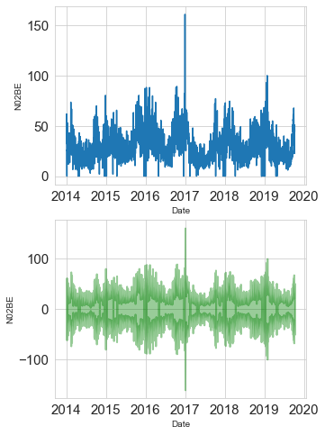

```python
fig, (ax1, ax2) = plt.subplots(2, 1,figsize = (5,8))
x = df.index
y = df['N02BE']
ax1.plot(df.index, df['N02BE'])
ax1.set(xlabel='Date', ylabel='N02BE')

# Since the values are positive we can show on both sides of Y axis to emphasize the growth
ax2.fill_between(x, y1=y, y2=-y, alpha=0.4, linewidth=2, color='green')
ax2.set(xlabel='Date', ylabel='N02BE')
```

From the last figure we notice similar patterns across the years with many fluctuations/oscillations

#### 4. Seasonal plot

To investigate if there are fluctuations we need inspect the seasonality of our time-series.

- First we extract the month and the year from our date column.
- Then we use the seaborn built in function **lineplot** to get a curve for each year.

The difference with the previous figure is that the data are plotted agains the individual "seasons". The data for each season are overlapped.

Is there any fluctuation you observe over the years?

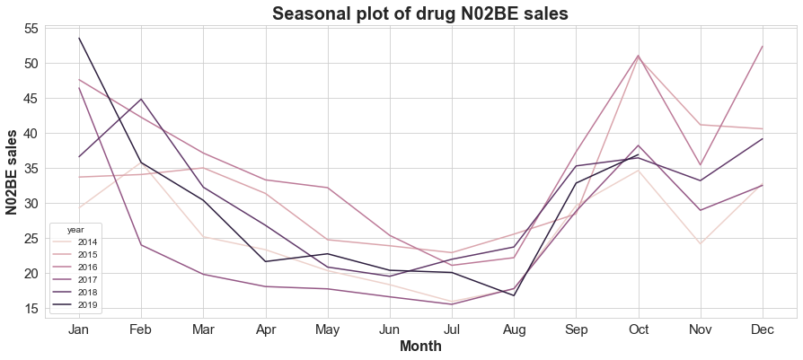

```python
# Prepare data
df['year'] = [d.year for d in df.index]
df['month'] = [d.strftime('%b') for d in df.index]
years = df['year'].unique()

# Seasonal plot
fig, ax = plt.subplots(figsize=(15, 6))
sns.lineplot(x= df['month'], y= df['N02BE'], hue = df['year'], ci=None)
ax.set_title('Seasonal plot of drug N02BE sales', fontsize = 20, loc='center', fontdict=dict(weight='bold'))
ax.set_xlabel('Month', fontsize = 16, fontdict=dict(weight='bold'))
ax.set_ylabel('N02BE sales', fontsize = 16, fontdict=dict(weight='bold'))
```

#### 5. Trend and seasonality plots

Using these type of visualizations we can identify easier the **trend** as well as the **years** in which the pattern changes.

The boxplots give us further insight into **large jumps or sharp drops and detection of outliers.**

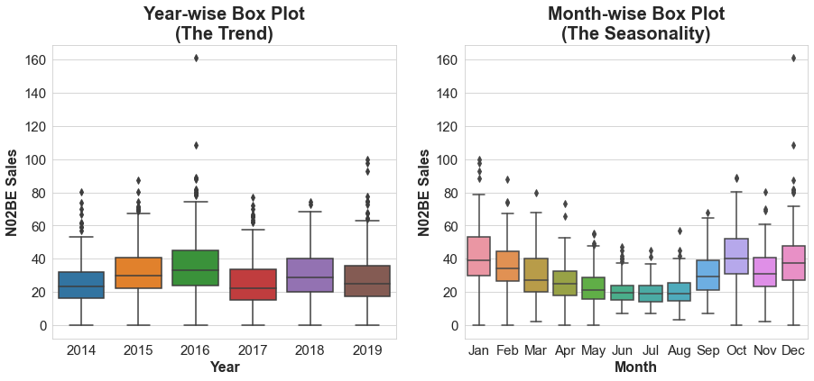

```python
fig, ax = plt.subplots(nrows=1, ncols=2, figsize=(15, 6))

sns.boxplot(x= df['year'], y= df['N02BE'], ax=ax[0])
ax[0].set_title('Year-wise Box Plot\n(The Trend)', fontsize = 20, loc='center', fontdict=dict(weight='bold'))
ax[0].set_xlabel('Year', fontsize = 16, fontdict=dict(weight='bold'))
ax[0].set_ylabel('N02BE Sales', fontsize = 16, fontdict=dict(weight='bold'))

sns.boxplot(x= df['month'], y= df['N02BE'], ax=ax[1])
ax[1].set_title('Month-wise Box Plot\n(The Seasonality)', fontsize = 20, loc='center', fontdict=dict(weight='bold'))
ax[1].set_xlabel('Month', fontsize = 16, fontdict=dict(weight='bold'))
ax[1].set_ylabel('N02BE Sales', fontsize = 16, fontdict=dict(weight='bold'))
```